# Statistics and Graphs for ABMGIS Book, Chapter 9

[figure not shown]

This R Markdown file shows how to do all of the spatial analysis for [Chapter 9](https://www.abmgis.org/Chapter9) of the book *Agent-Based Modelling and Geographical Information Systems: A Practical Primer'* (www.abmgis.org). The chapter presented a range of statistics and algorithms that can be used to compare two spatial data sets. These are important for modelling because, at some point, it will be necessary to compare a model outcome to some real-world data in order to assess how reliable the model is. This script shows how to calculate most of the statistics themselves, before [Chapter 10](https://www.abmgis.org/Chapter10) elaborates on how to evaluate the success of a model more broadly, part of which includes making use of the methods discussed here.

# How to run this script

This script can be loaded into [R Studio](https://www.rstudio.com/products/RStudio/) and then either used to build a pdf or html file using the *Knit* button, or each code chunk can be run interactively. The only setting that needs to be changed is the `setwd` line in the code chunk below. That link needs to point to the `Resources` folder which contains this script. For example, if your username is `Sarah` and you have downloaded the [entire book from github](https://github.com/abmgis/abmgis) and put it in your `My Documents` folder, then the location would be something like:

- `C:\Users\Sarah\My Documents\abmgis\Chapter09-SpatialStatistics\Resources'`.

```r
setwd("/Users/nick/research_not_syncd/git_projects/abmgis/Chapter09-SpatialStatistics/Resources")
```

# Initialisation

Initialise the required R libraries. If R complains that any of these are not available, you can install them with `install.packages("PackageName")`.

```r
# Remember the default margins (useful later when they need changing temporarily)
default.mar <- par("mar")

library(GISTools)   # A great GIS package; lots of other useful dependencies loaded as well
library(rgdal)      # For reading shapefiles
library(hydroGOF)   # Has an rmse() function
library(classInt)   # Jenks natural breaks
library(spatstat)   # For Ripley's K and others
library(spatialEco) # For Nearest Neighbour Indea
library(raster)     # For generating raster grids
library(parallel)   # For doing more than one thing at a time (quicker when you have a multi-core CPU)
library(spdep)      # For GI*
library(xtable)     # For making latex/html tables
```

# Download Example Data - Crime in West Yorkshire

This document runs the examples of different statistics that can be used to calculate the error between two data sets (i.e. a model output and 'real' observed data).

The examples here will make use of three example datasets that are similar, but not identical. These are all the crimes that occurred in West Yorkshire in May 2013, May 2014 and May 2015. They are available to download from [data.police.uk](https://data.police.uk/).

Henceforth the data will be used as follows:

- May 2014 will be the observed ('real') data
- May 2013 will be the hypothetical results from a simulation run (simulated1). These will be randomised a bit so that simulated1 appears to be worse than simulated2
- May 2015 will be the hypothetical results from a different simulation run (simulated2)

Some of the examples will use statistics that require aggregate data, so the following will also read LSOA boundaries and aggreagte the crime data. These were downloaded from [data.gov.uk](https://data.gov.uk/dataset/lower_layer_super_output_area_lsoa_boundaries) and West Yorkshire was extracted separately.

```r
# Because there is some randomisation in the crime data, only re-read it if this is the first time the script has run.
# Otherwise the results will be slightly different each time.

if (file.exists("./statistics.RData")) {
  print("Loading data from RData file")
  load("./statistics.RData")
} else {
  print("Re-reading data and re-randomising")
  # Read crime from May 2015
  crime.15 <- read.csv("data/2015-05-west-yorkshire-street.csv")
  # Remove the 'context' column and get rid of any incomplete rows
  crime.15$Context <- NULL
  crime.15 <- crime.15[complete.cases(crime.15),]
  # Create a spatial polygons data frame
  crime.15.spdf <- SpatialPointsDataFrame(coords=crime.15[,c("Longitude","Latitude")], data=crime.15, proj4string = CRS("+init=epsg:4326"))
  # Transform that data to the British National Grid coordinate system and rename it 'simulated' (i.e. simulated data)
  # (Note that the proj4string for BNG came from: http://spatialreference.org/ref/epsg/osgb-1936-british-national-grid/)
  simulated2 <- spTransform(crime.15.spdf, CRS("+proj=tmerc +lat_0=49 +lon_0=-2 +k=0.9996012717 +x_0=400000 +y_0=-100000 +ellps=airy +datum=OSGB36 +units=m +no_defs "))


  # Do the same for from May 2014 and 2013
  crime.14 <- read.csv("data/2014-05-west-yorkshire-street.csv")
  crime.14$Context <- NULL
  crime.14 <- crime.14[complete.cases(crime.14),]
  crime.14.spdf <- SpatialPointsDataFrame(coords=crime.14[,c("Longitude","Latitude")], data=crime.14, proj4string = CRS("+init=epsg:4326"))
  observed <- spTransform(crime.14.spdf, CRS("+proj=tmerc +lat_0=49 +lon_0=-2 +k=0.9996012717 +x_0=400000 +y_0=-100000 +ellps=airy +datum=OSGB36 +units=m +no_defs "))
  crime.13 <- read.csv("data/2013-05-west-yorkshire-street.csv")
  crime.13$Context <- NULL
  crime.13 <- crime.13[complete.cases(crime.13),]
  crime.13.spdf <- SpatialPointsDataFrame(coords=crime.13[,c("Longitude","Latitude")], data=crime.13, proj4string = CRS("+init=epsg:4326"))
  simulated1 <- spTransform(crime.13.spdf, CRS("+proj=tmerc +lat_0=49 +lon_0=-2 +k=0.9996012717 +x_0=400000 +y_0=-100000 +ellps=airy +datum=OSGB36 +units=m +no_defs "))

  # Randomise the simulated1 points by upto NUDGE meters because simulated1 data should be 'worse' than simulated2.
  NUDGE <- 400
  simulated1@coords[,'Longitude'] <- simulated1@coords[,'Longitude'] + runif(nrow(simulated1), -1*NUDGE, NUDGE)
  simulated1@coords[,'Latitude'] <- simulated1@coords[,'Latitude'] + runif(nrow(simulated1), -1*NUDGE, NUDGE)

  # Read the LSOA boundaries and LAD boundaries
  lsoa <- readOGR(dsn = "./data", "west_yorkshire_lsoa_2011" )
  lad <- readOGR("./data/", "West_Yorkshire_lad_2011")
  # The boundaries are British National Grid, but the proj4string varies slightly so use the same one as the crime data
  proj4string(lsoa) <- CRS("+proj=tmerc +lat_0=49 +lon_0=-2 +k=0.9996012717 +x_0=400000 +y_0=-100000 +ellps=airy +datum=OSGB36 +units=m +no_defs")
  proj4string(lad) <- CRS("+proj=tmerc +lat_0=49 +lon_0=-2 +k=0.9996012717 +x_0=400000 +y_0=-100000 +ellps=airy +datum=OSGB36 +units=m +no_defs")

  # Remove any points from outside of the boundaries (as these will make the maps look funny)

  observed <- gIntersection(observed, lad, byid=T)
  simulated1 <- gIntersection(simulated1, lad, byid=T)
  simulated2 <- gIntersection(simulated2, lad, byid=T)

  # Now aggregate the points
  lsoa@data$observed <- 0 # Get the new colum ready
  lsoa@data$simulated1 <- 0 # Get the new colum ready
  lsoa@data$simulated2 <- 0 # Get the new colum ready
  lsoa@data$observed <- poly.counts(observed, lsoa)
  lsoa@data$simulated1 <- poly.counts(simulated1, lsoa)
  lsoa@data$simulated2 <- poly.counts(simulated2, lsoa)

  save.image(file="statistics.RData")
}
```

```
## [1] "Loading data from RData file"
```

Do a graph to show the differences between the two data sets

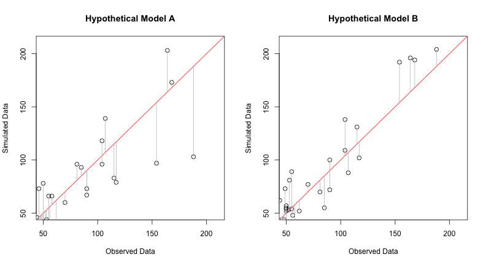

```r
# Some x values
x <- lsoa@data$observed
# Identical y values so that the linear model (line of best fit) is a straight line through the origin
y <- x
# Some 'modelled' data with randomness
y1 <- lsoa@data$simulated1
# Line of best fit
m <- lm( y ~ x )
# Residuals
res1 <- signif(residuals(m), 5)
pre1 <- predict(m)

# Another model with some more randomness
y2 <- lsoa@data$simulated2
res2 <- signif(residuals(m), 5)
pre2 <- predict(m)

# Plot the data and regression line
doplot <- function () {
  par(mfrow=c(1,2))

  # First model
  plot(x,y1, main = "Hypothetical Model A", xlab="Observed Data", ylab="Simulated Data", ylim=c(50,210), xlim=c(50,210), cex=1.2)
  abline(m, col="red")
  # Add residuals
  segments(x, y1, x, pre1, col="gray")

  # Second model
  plot(x,y2, main="Hypothetical Model B", xlab="Observed Data", ylab="Simulated Data",  ylim=c(50,210), xlim=c(50,210), cex=1.2)
  abline(m, col="red")
  segments(x, y2, x, pre2, col="gray")

  par(mfrow=c(1,1))
}



# Plot for the knitr'd document
doplot()
```

```r
# And a pdf for the book:
pdf(file="figures/regression_graph.pdf", width=9, height=5)
doplot()
dev.off()
```

And also do a map

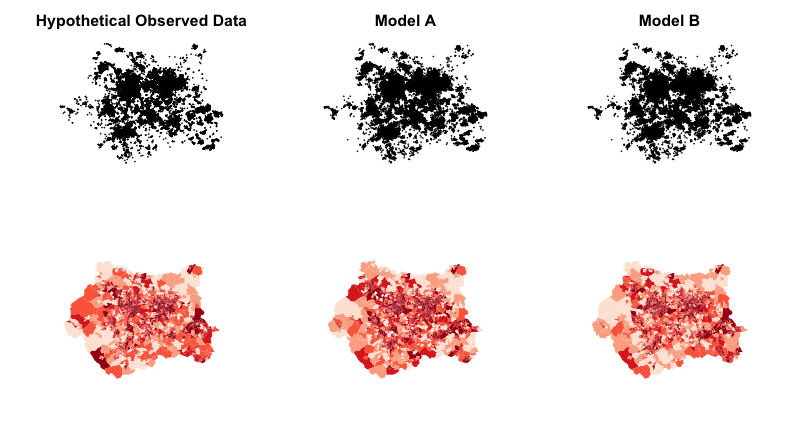

```r
doplot <- function() {

par(mfrow=c(2,3))
plot(observed, main = "Hypothetical Observed Data", cex.main=2.0, cex=0.2)
plot(simulated1, main = "Model A", cex.main=2.0, cex=0.2)
plot(simulated1, main = "Model B", cex.main=2.0, cex=0.2)

choropleth(lsoa, lsoa$observed, border=NA)
choropleth(lsoa, lsoa$simulated1, border=NA)
choropleth(lsoa, lsoa$simulated2, border=NA)

} # doPlot



# Plot for the knitr'd document
doplot()
```

```r
# And a pgn for the book:
png(file="figures/hypothetical_data.png", width = 1080, height = 600, units = "px")
doplot()
dev.off()
```

# A-Spatial Statistics: RSS, R2, SRMSE

Generate some non-spatial statistics.

First, **Residual Sum of Squares (RSS)**. This is easy, just add up the square of the differences.

```r
rss1 <- sum( ( lsoa@data$observed - lsoa@data$simulated1 )^2 )
rss2 <- sum( ( lsoa@data$observed - lsoa@data$simulated2 )^2 )
```

Now do **R-Squared**.

```r
# Get r.squared by creating a linear regression model (with lm()) and calculating R^2 on the model
r.squared1 <- summary(lm(observed ~ simulated1, data=lsoa@data))$r.squared
r.squared2 <- summary(lm(observed ~ simulated2, data=lsoa@data))$r.squared
```

Now do **RMSE**.

```r
rmse1 <- rmse(lsoa@data$simulated1, lsoa@data$observed)
rmse2 <- rmse(lsoa@data$simulated2, lsoa@data$observed)
```

Summarise those results in a table:

```r
print(xtable(data.frame(
    "Model" = c("Model A", "Model B"),
    "RSS"  = c(rss1, rss2),
    "R-squared" = c(r.squared1, r.squared2),
    "RMSE" = c(rmse1, rmse2)
  )))
```

[output not shown]

# Spatial Statistics

## Visual Comparison

Compare points, density, and area counts.

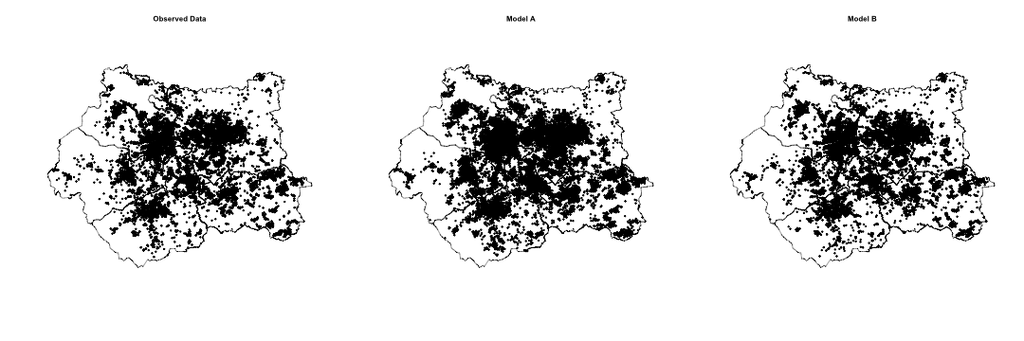

```r
# Standard shading across all maps
COLOURS <- brewer.pal(9,'Blues')
BREAKS <- 8
WIDTH <- 17
WIDTH.png <- 1080
HEIGHT <- 5
HEIGHT.png <- 420
TITLE_SIZE <- 1.0


# Points

plot.points <- function() {
  par(mfrow=c(1,3))
  plot(lad, lwd=0.5)
  plot(observed, add=T, pch=1, cex=0.35)
  title("Observed Data", cex.main=TITLE_SIZE)
  plot(lad, lwd=0.5)
  plot(simulated1, add=T, pch=1, cex=0.35)
  title("Model A", cex.main=TITLE_SIZE)
  plot(lad, lwd=0.5)
  plot(simulated2, add=T, pch=1, cex=0.35)
  title("Model B", cex.main=TITLE_SIZE)
  par(mfrow=c(1,1))
}

plot.points() # For knitr
```

```r
pdf(file="figures/visual-points.pdf", width=WIDTH, height=HEIGHT) # For the book
plot.points()
dev.off()
```

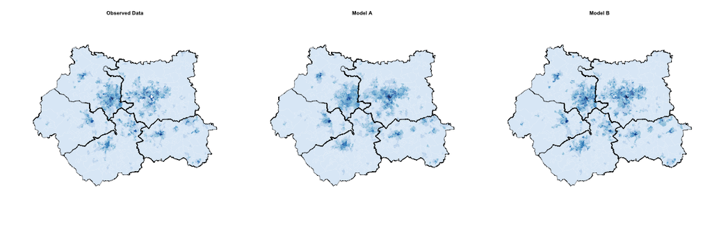

```r
# Aggregate

# Calculate shading
agg.interval <- classIntervals(lsoa@data$observed / poly.areas(lsoa), n = BREAKS, style = 'kmeans')$brks
agg.shades <- shading(agg.interval, cols=COLOURS)

# Plot aggregate
plot.aggregate <- function() {
  par(mfrow=c(1,3))
  choropleth(lsoa, lsoa@data$observed / poly.areas(lsoa), shading=agg.shades, lty=0)
  title("Observed Data", cex.main=TITLE_SIZE)
  plot(lad, add=T, lwd=0.5, col=rgb(1, 1, 1, 0.0)) # (White fill and fully transparent)

  choropleth(lsoa, lsoa@data$simulated1 / poly.areas(lsoa), shading=agg.shades, lty=0)
  title("Model A", cex.main=TITLE_SIZE)
  plot(lad, add=T, lwd=0.5, col=rgb(1, 1, 1, 0.0)) # (White fill and fully transparent)

  choropleth(lsoa, lsoa@data$simulated2 / poly.areas(lsoa), shading=agg.shades, lty=0)
  title("Model B", cex.main=TITLE_SIZE)
  plot(lad, add=T, lwd=0.5, col=rgb(1, 1, 1, 0.0)) # (White fill and fully transparent)
  par(mfrow=c(1,1))
}
plot.aggregate() # For knitr
```

```r
#pdf(file="figures/visual-aggregate.pdf", width=WIDTH, height=HEIGHT) # For the book
png(file="figures/visual-aggregate.png", width = WIDTH.png, height = HEIGHT.png, units = "px")
plot.aggregate() # For knitr
dev.off()
```

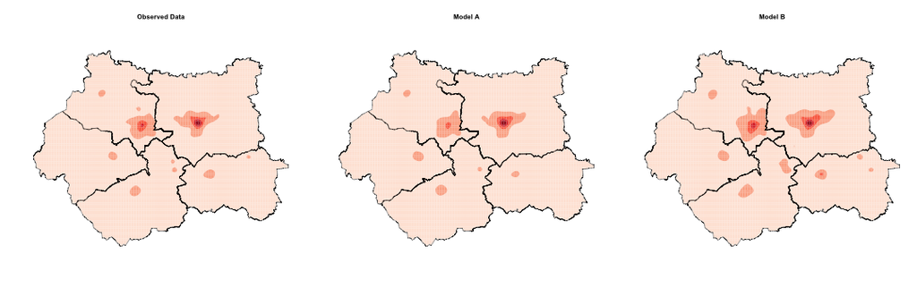

```r
# KDE

# Compute KDE
observed.kde <- kde.points(  pts=observed,   h=3000, n=100, lims=lad) # 250m bandwidth and 100x100 grid
simulated1.kde <- kde.points(pts=simulated1, h=3000, n=100, lims=lad) # 250m bandwidth and 100x100 grid
simulated2.kde <- kde.points(pts=simulated2, h=3000, n=100, lims=lad) # 250m bandwidth and 100x100 grid
# Calculate shading
kde.interval <- classIntervals(observed.kde@data$kde, n = BREAKS, style = 'kmeans')$brks
kde.shades <- shading(kde.interval, cols=COLOURS)
# Plot KDE
plot.kde <- function() {
  par(mfrow=c(1,3))
  masker = poly.outer(simulated1.kde,lad,extend=100)

  level.plot(observed.kde)
  add.masking(masker)
  plot(lad, add=T, lwd=0.5, col=rgb(1, 1, 1, 0.0)) # (White fill and fully transparent)
  title("Observed Data", cex.main=TITLE_SIZE)

  level.plot(simulated1.kde)
  add.masking(masker)
  plot(lad, add=T, lwd=0.5, col=rgb(1, 1, 1, 0.0)) # (White fill and fully transparent)
  title("Model A", cex.main=TITLE_SIZE)

  level.plot(simulated2.kde)
  add.masking(masker)
  plot(lad, add=T, lwd=0.5, col=rgb(1, 1, 1, 0.0)) # (White fill and fully transparent)
  title("Model B", cex.main=TITLE_SIZE)
  par(mfrow=c(1,1))
}
plot.kde() # For knitr
```

```r
pdf(file="figures/visual-kde.pdf", width=WIDTH, height=HEIGHT) # For the book
#png(file="figures/visual-kde.png", width = WIDTH.png, height = HEIGHT.png, units = "px")
plot.kde()
dev.off()
```

## Spatial Description - *NNI* and *K*

```r
# NNI
observed.nni <- nni(observed, win='extent')
simulated1.nni <- nni(simulated1, win='extent')
simulated2.nni <- nni(simulated2, win='extent')
```

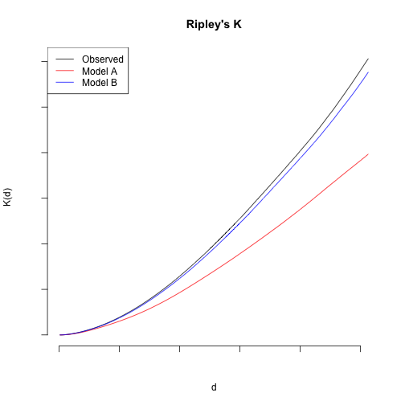

```r
# K
observed.k <- Kest(unique.ppp(as.ppp(observed)), correction='border')
simulated1.k <- Kest(unique.ppp(as.ppp(simulated1)), correction='border')
simulated2.k <- Kest(unique.ppp(as.ppp(simulated2)), correction='border')

# Plot K
WIDTH <- 10
HEIGHT <- 5

plot(observed.k$border, type='l', xlab="d", ylab="K(d)", axes=F)
axis(1, labels=F)
axis(2, labels=F)
title("Ripley's K")
lines(simulated1.k$border, type='l', col='red')
lines(simulated2.k$border, type='l', col='blue')
legend("topleft", legend = c('Observed', 'Model A','Model B'), col=c("black","red","blue"), lty=c(1,1,1))
```

```r
# Now for the book
pdf(file="figures/k_function.pdf", width=WIDTH, height=HEIGHT)
plot(observed.k$border, type='l', xlab="d", ylab="K(d)", axes=F)
axis(1, labels=F)
axis(2, labels=F)
title("Ripley's K")
lines(simulated1.k$border, type='l', col='red')
lines(simulated2.k$border, type='l', col='blue')
legend("topleft", legend = c('Observed', 'Model A','Model B'), col=c("black","red","blue"), lty=c(1,1,1))
dev.off()
```

Nearest Neighbour Indices are:

- Observed: 0.2530316, -203.3406287, 0, 183.9911817, 46.5555884
- Model A: 0.5326359, -130.2044582, 0, 179.45352, 95.5833864
- Model B: 0.2371359, -218.5905778, 0, 175.2310725, 41.553572

## LISA Statistics

These statistics are used to identify clustering at a local (neighbourhood) level

### Dual KDE

For this simple implementiont of Dual KDE, we simply take the observed KDE maps away from the simulated maps. The most complicated thing about this bit is getting the shading right.

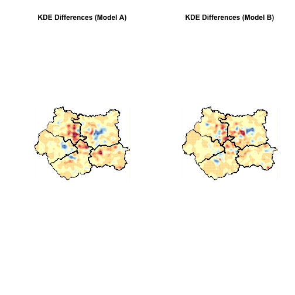

```r
# Take one away from the other. Slightly convoluted because there is no overloaded 'minus' operator
kde.diff.1 <- simulated1.kde
kde.diff.1@data <- simulated1.kde@data - observed.kde@data
kde.diff.2 <- simulated2.kde
kde.diff.2@data <- simulated2.kde@data - observed.kde@data

# Map them.
# Calculate shading. Do this manually. Couldn't get this to work
kde.diff.interval <- c(
 -0.000000002035, # Min
 -0.000000001017,
 -0.0000000005085,
  0,
  0.0000000002432,
  0.0000000004864,
  0.0000000009728 # Max
)

#kde.diff.interval.shades <- shading(kde.diff.interval, cols=brewer.pal(length(kde.diff.interval)+1,'RdYlBu'))

N.LEVELS <- 10
kde.diff.interval.shades <- auto.shading(
  x = kde.diff.1$kde,
  n=N.LEVELS,
  cols=brewer.pal(n=N.LEVELS+1 , name="RdYlBu" ),
  cutter = sdCuts
  )

plot.kde.diff <- function() {
  par(mfrow=c(1,2))
  masker = poly.outer(simulated1.kde,lad,extend=100)

  level.plot(kde.diff.1, shades=kde.diff.interval.shades)
  add.masking(masker)
  plot(lad, add=T, lwd=0.5, col=rgb(1, 1, 1, 0.0)) # (White fill and fully transparent)
  title("KDE Differences (Model A)", cex.main=TITLE_SIZE)
  #choro.legend("topleft", sh=kde.diff.interval.shades, cex=0.7)

  level.plot(kde.diff.2, shades=kde.diff.interval.shades)
  add.masking(masker)
  plot(lad, add=T, lwd=0.5, col=rgb(1, 1, 1, 0.0)) # (White fill and fully transparent)
  title("KDE Differences (Model B)", cex.main=TITLE_SIZE)
}


plot.kde.diff() # For knitr
```

```r
pdf(file="figures/kde-diff.pdf", width=WIDTH, height=HEIGHT) # For the book
#png(file="figures/kde-diff..png", width = WIDTH.png, height = HEIGHT.png, units = "px")
plot.kde.diff()
dev.off()
```

### GI*

It is possible to coduct Getis-Ord GI* analysis in R, but in this case we have used ArcMap. All the script does here is write out the data so that it can be read by ArcGIS.

```r
writeOGR(lsoa, dsn = "gi_star", layer = "lsoa", driver = "ESRI Shapefile", overwrite_layer = TRUE)
```

## Multi-Scale Error Analysis

This is the R implementation of the Multiscale Spatial Error Assessment method (aka [Multiscale Validation](http://www.geog.leeds.ac.uk/courses/other/programming/practicals/general/modelling/validation/multiscale-code/2.html)).

It is based on the R code that is being developed as part of the [Multi Scale Error Analysis](https://github.com/nickmalleson/Multi-Scale-Error-Analysis) repository that has been produced as part of an academic paper (currently in review) that uses the method in earnest.

Thanks to Lex Comber and Chris Brunsdon for their excellent book 'R for Spatial Analysis and Mapping'. I got most of the R GIS stuff from there.

Brunsdon, C and Comber, L (2015) *An Introduction to R for Spatial Anaysis and Mapping*. Sage

### Define the Error Assessment Method

The following funtion defines the method. See the [Multi Scale Error Analysis](https://github.com/nickmalleson/Multi-Scale-Error-Analysis) repository for the full code, comments, and documentation.

```r
msea <- function(points1, points2, N=20, the.box=NULL) {
  if ( proj4string(points1) != proj4string(points2) ) {
    warning("The points1 and points2 projections are different, this will probably lead to catastrophic results!")
  }
  # A bounding box around all points
  bb <- if (is.null(the.box)) bbox(points1 + points1) else the.box
  results <- list()
  cell.areas <- c() # The area of the cells
  num.cells <- c()  # The number of cells in each iteration

  # Create the grids - adapted from Brunsdon & Comber (2015, p150)
  for (i in seq(1,N)) {
    cell.width <- (bb[1,2] - bb[1,1]) / i
    cell.height <- (bb[2,2] - bb[2,1]) / i
    for (shift in 1:3) { # Shift the grid. 1=no shift, 2=shift vertically, 3=shift horizontally
      cell.areas <- c(cell.areas, (cell.width * cell.height) ) # Also remember the cell area for later

      # Variables that change depending on the shift
      offset <- -1 # The centre of the lower-left cell
      dimensions <- c(-1,-1) # The number of cells (horizontal, vertical)

      if (shift==1) { # This is the grid with no shifting (i.e. it fits perfectly over the study area)

        centre.x <- bb[1,1] + ( cell.width / 2 )
        centre.y <- bb[2,1] + ( cell.height / 2 )
        offset <- c(centre.x, centre.y) #  No offset, the grid will just cover all the points
        dimensions = c(i,i) # Number of cells. As no shifting, don't need to add an extra row or column

      } else if (shift ==2 ) {  # Shift vertically.

        centre.x <- bb[1,1] + ( cell.width / 2 ) # (same as with no shifting)
        centre.y <- bb[2,1] #+ ( cell.height / 2 ) # (move grid down by exactly one half the height of a cell)
        offset <- c(centre.x, centre.y) # Now the grid will start slightly south of the points bounding box
        dimensions = c(i,i+1) # Number of cells. One extra cell in vertical dimension.

      } else if (shift == 3) { # Shift horizontally

        centre.x <- bb[1,1] #+ ( cell.width / 2 ) # (move grid left by exactly one half the heightwidth of a cell)
        centre.y <- bb[2,1] + ( cell.height / 2 )  # (same as with no shifting)
        offset <- c(centre.x, centre.y) # Now the grid will start slightly west of the points bounding box
        dimensions = c(i+1,i) # Number of cells. One extra cell in horizontal dimension.

      } else {
        stop(paste("Internal error in grid shifting - should not have shift:",shift))
      }

      grd <- GridTopology(
        cellcentre.offset = offset,
        cellsize = c(cell.width, cell.height),
        cells.dim = dimensions
      )
      number.of.cells <- dimensions[1] * dimensions[2] # (will change with grid shifting)
      num.cells <- c(num.cells, number.of.cells) # Remember the number of cells in this iteration
      spdf <- SpatialPolygonsDataFrame(
        as.SpatialPolygons.GridTopology(grd),
        data = data.frame(c(1:number.of.cells)),
        match.ID = FALSE
      )
      proj4string(spdf) <- proj4string(points1)
      names(spdf) <- "CellID" # Name the column
      spdf@data$points1 <- poly.counts(points1, spdf)
      spdf@data$points2 <- poly.counts(points2, spdf)
      spdf@data$p1.pct <- 100 * spdf@data$points1 / sum(spdf@data$points1 )
      spdf@data$p2.pct <- 100 * spdf@data$points2 / sum(spdf@data$points2 )
      spdf@data$diff <- spdf@data$points1 - spdf@data$points2
      spdf@data$abs.diff <- abs(spdf@data$points1 - spdf@data$points2)
      spdf@data$abs.pct.diff <- abs(spdf@data$p1.pct - spdf@data$p2.pct)

      # Store the results, remembering that each iteration will make 3 different results grids due to shifting
      # (thanks AE for working out this formula!)
      results[[ shift + (3*(i-1)) ]] <- spdf

    } # for shifting grids
  } # for cell sizes

  # Now calculte the errors
  rss <- c() # Residual sum of squares
  r.squared <- c()
  rmse <- c()
  for (i in 1:length(results)) {
    the.result <- results[[i]]@data # Convenience for referring to the current result we're looking at
    rss <-  c(rss, sum( ( the.result$points1 - the.result$points2 )**2 ))
    r.squared <- c(r.squared, summary(lm(the.result$points1 ~ the.result$points2, data=the.result))$r.squared )
    rmse <- c(rmse, rmse(the.result$points1, the.result$points2) )
  }

  # Return the results
  r <- list(
    "results" = results,
    "cell.areas" =cell.areas,
    "num.cells" = num.cells,
    "rss" = rss,
    "r.squared" = r.squared,
    "rmse" = rmse
  )
  return(r)
} # function
```

Now run the function

```r
N <- 20
box <- bbox(observed+simulated1+simulated2) # Calculate once now to save re-calculating again later
r1 <- msea(observed, simulated1, N, the.box = box)
r2 <- msea(observed, simulated2, N, the.box = box)
```

### Map the results

(Sanity) check that the shifting has worked for the first five grids

```r
par(mfrow=c(5,3))
par(mar=c(rep(0.1,4)))
for (i in 1:15) {
  choropleth(r1$results[[i]],
             r1$results[[i]]@data$abs.pct.diff,
             xlim=c(380000,460000), ylim=c(400000,500000)
      )
  points(observed)
}
```

[figure not shown]

```r
par(mar=default.mar)
```

For a sanity check: map the total number of points for some different grids

```r
par(mfrow=c(4,4))

for (i in 4:1) {
  index <- round(length(r1$results) / i )
  choropleth(r1$results[[index]], r1$results[[index]]@data$points1, main=paste("Observed (model one)",i))
}

for (i in 4:1) {
  index <- round(length(r2$results) / i )
  choropleth(r2$results[[index]], r2$results[[index]]@data$points1, main=paste("Observed (model two)",i))
}

for (i in 4:1) {
  index <- round(length(r1$results) / i )
  choropleth(r1$results[[index]], r1$results[[index]]@data$points2, main=paste("Simulated1 (model one)",i))
}

for (i in 4:1) {
  index <- round(length(r1$results) / i )
  choropleth(r2$results[[index]], r2$results[[index]]@data$points2, main=paste("Simulated2 (model two)",i))
}
```

[figure not shown]

Now map the difference in the proportions

```r
par(mfrow=c(2,4))
for (i in 4:1) {
  index <- round(length(r1$results) / i )
  choropleth(r1$results[[index]], r1$results[[index]]@data$abs.pct.diff, main=paste("Abs % Diff (Model A)",i))
}
for (i in 4:1) {
  index <- round(length(r2$results) / i )
  choropleth(r2$results[[index]], r2$results[[index]]@data$abs.pct.diff, main=paste("Abs % Diff (Model B)",i))
}
```

[figure not shown]

Finally make a fuzzy grid of all results

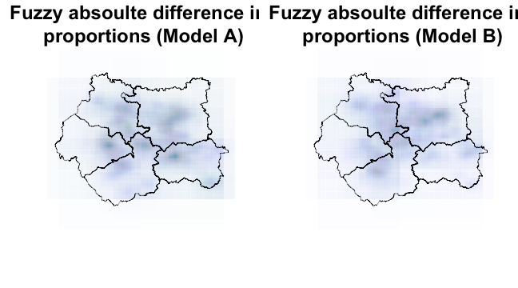

```r
map.fuzzy <- function() { # A function so that it can be run once for knitr, and again for the book
  par(mfrow=c(1,2))

  statistic <- "abs.prop.diff" # The statistic to map
  count <- 1 # Just for the graph labels
  label <- c("A","B") # Want the models to be called 'A' and 'B' not '1' and '2'
  num.results <- length(r1$results) # The total number of results grids (3 for each resolution, i.r. 3*N)

  # Shading. I know that model 1 has the greatest difference, so use that one for shading.
  # Pick the result of the smallest grid as this will probably have the greatest difference
  # (TODO: work out which model has greatest difference)
  shades <- shading(
      classIntervals(r1$results[[length(r1$results)]]@data$abs.pct.diff, n = 8, style = 'equal')$brks,
      cols=add.alpha(brewer.pal(9,'PuBu'), (1/num.results) )
  )

  for (r in list(r1,r2)) {
    last.result <- r$results[[length(r$results)]] # Convenience for list result generated (the smallest grid)

    # Draw the smallest grid
    choropleth(
      last.result, last.result@data$abs.pct.diff,
      shading = shades,
      main=paste("Fuzzy absoulte difference in \n proportions (Model ",label[count],")", sep=""),
      lty=0,
      cex.main=2.0
      )

    # Now do the remainder of them
    for ( index in 1:(num.results-1)) {
      choropleth( r$results[[index]], r$results[[index]]@data$abs.pct.diff,
      shading = shades,
      lty=0,
      add=TRUE)
    }
    # Add the area boundaries with transparent fill
    plot(lad, lwd=0.5, col=rgb(1, 1, 1, 0.0), add=T)

    # Finally the legend
    #choro.legend("topleft", sh=shades, cex=0.7)

    count <- count + 1
  }
}
# Make the figures

map.fuzzy() # For knitr
```

```r
png(filename = "figures/map-fuzzy.png", width=1080, height=500) # For the book
map.fuzzy()
dev.off()
```

### Calculate and graph the errors

Calculate the following errors:

- **Residual Sum of Squares (RSS)** (This is easy, just add up the square of the differences)
- **R-Squared**
- **Root Mean Square Error (RMSE)**

  And then graph them using two difference x axes:
- The number of cells used
- The square area of an individual cell (smallest cells first)

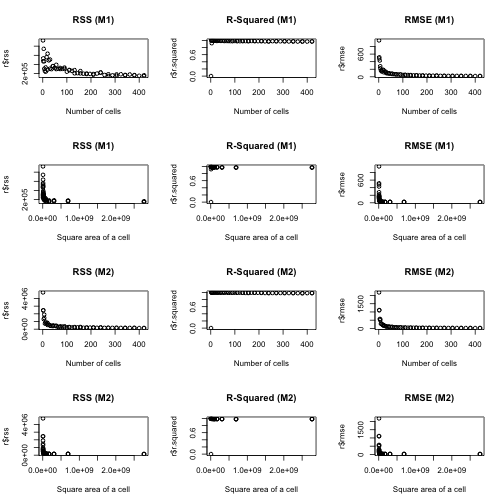

```r
# Go through all of the results and calculate errors

par(mfrow=c(4,3))

count <- 1
for (r in list(r1,r2)) {
  title <- paste("(M",count,")",sep="")
  plot(x=r$num.cells, y=r$rss, type='p', main=paste("RSS",title), xlab="Number of cells")
  plot(x=r$num.cells, y=r$r.squared, type='p', main=paste("R-Squared",title), xlab="Number of cells")
  plot(x=r$num.cells, y=r$rmse, type='p', main=paste("RMSE",title), xlab="Number of cells")
  plot(x=rev(r$cell.areas), y=r$rss, type='p', main=paste("RSS",title), xlab="Square area of a cell")
  plot(x=rev(r$cell.areas), y=r$r.squared, type='p', main=paste("R-Squared",title), xlab="Square area of a cell")
  plot(x=rev(r$cell.areas), y=r$rmse, type='p', main=paste("RMSE",title), xlab="Square area of a cell")
  count <- count + 1
}
```

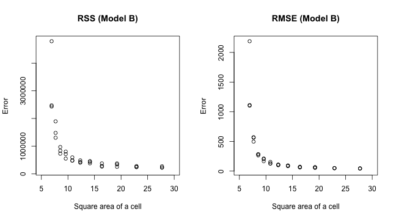

```r
r <- r2

title <- "(Model B)"
xlim <- c(5,30)
xlab <- "Square area of a cell"
ylab <- "Error"

options("scipen"=100, "digits"=4) # Encourage standard (rather than scientific) notation
for (i in 1:2) { # Do once for knitr, once for the book

  if (i==2) pdf(file = "figures/graph_multiscale_error-final.pdf",  width=9, height=5 ) # For the book

  par(mfrow=c(1,2))
  plot(x=rev(r$cell.areas/1000000), y=r$rss,       type='p', main=paste("RSS",title), xlab=xlab, xlim=xlim, ylab=ylab)
  #plot(x=rev(r$cell.areas/1000000), y=r$r.squared, type='p', main=paste("R-Squared",title), xlab=xlab, xlim=xlim, ylab=ylab)
  plot(x=rev(r$cell.areas/1000000), y=r$rmse,      type='p', main=paste("RMSE",title), xlab=xlab, xlim=xlim, ylab=ylab )

  if (i==2) dev.off()
}
```

Save all the data so we can just reload if we want to

```r
save.image("./statistics_final.RData")
```